# Statistical Methods for Reliability Data

Chapter 8 - Maximum Likelihood for Log-Location-Scale Distributions

W. Q. Meeker, L. A. Escobar, and J. K. Freels

2018-04-11

# Shockabsorber Data Set - Both Failure Modes

```r
ShockAbsorber.ld <- frame.to.ld(shockabsorber,
                                response.column = 1,
                                censor.column = 3,
                                time.units = "Kilometers")
```

## Create an `mleprobplot` array

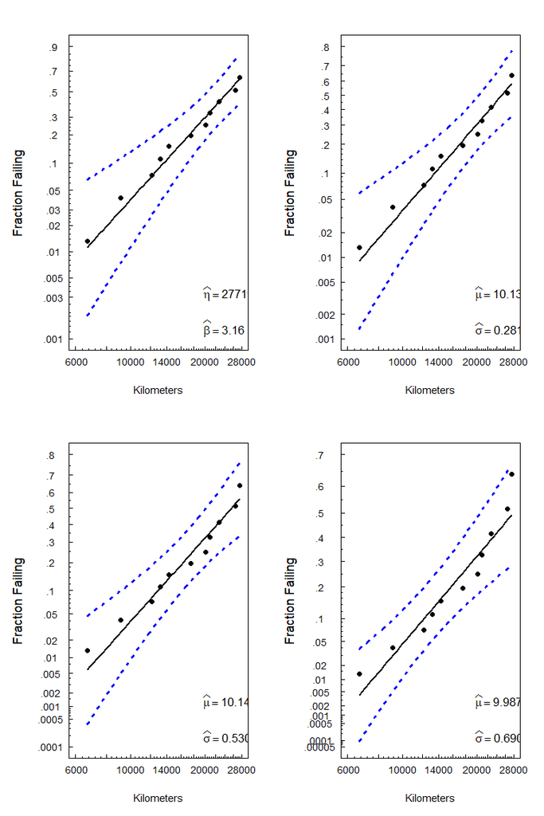

```r
mleprobplot(ShockAbsorber.ld, distribution="Weibull")
mleprobplot(ShockAbsorber.ld, distribution = "loglogistic")
mleprobplot(ShockAbsorber.ld, distribution = "lognormal")
mleprobplot(ShockAbsorber.ld, distribution = "frechet")
```

## Create an `mleprobplot` array

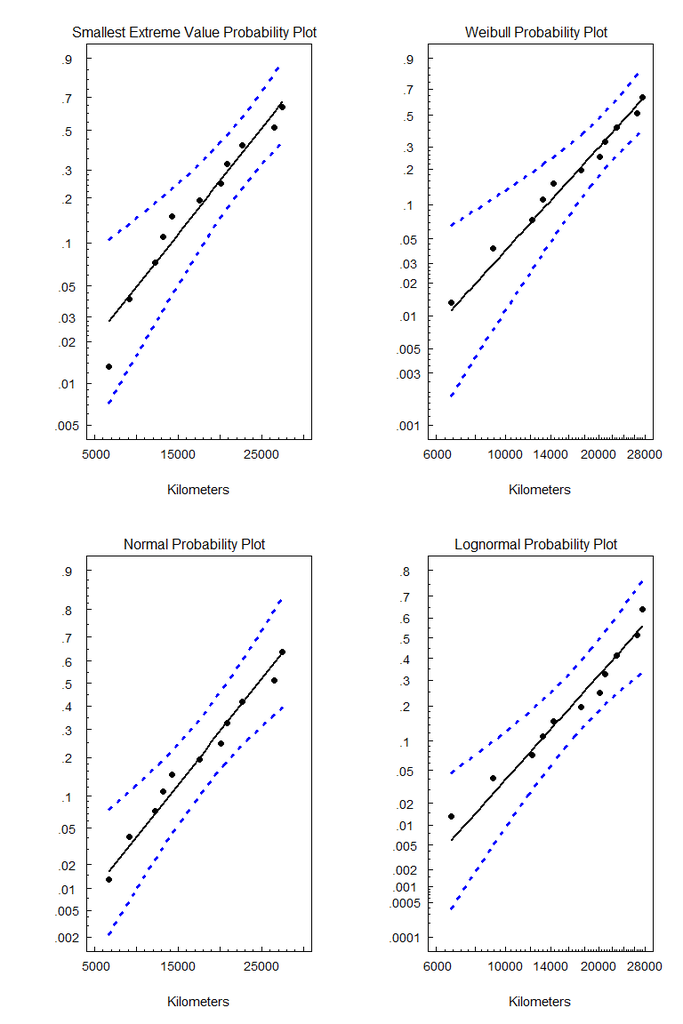

```r
four.mleprobplot(ShockAbsorber.ld)
```

## Create an `mlest` object

```r
ShockAbsorber.mlest <- mlest(ShockAbsorber.ld,
                             distribution = "Weibull")
print(ShockAbsorber.mlest)$ll.text
```

```
[1] "The maximum value of the log-likelihood function for the shockabsorber  (assuming the Weibull distribution is correct) was found to be -124"
```

```r
print(ShockAbsorber.mlest)$mttf.text
```

```
[1] "The ML estimate of mean time to failure (MTTF) for the shockabsorber (assuming the Weibull distribution is correct) was found to be 24812 Kilometers. An approximate 95% confidence interval on the MTTF is [20202, 30472]."
```

```r
print(ShockAbsorber.mlest)$mle.table
```

```
                      MLE   Std.Err.  95% Lower  95% Upper
mu             1.0230e+01 1.0989e-01    10.0145 1.0445e+01
sigma          3.1641e-01 7.3165e-02     0.2011 4.9783e-01
Weibull (eta)  2.7719e+04 3.0460e+03 22347.7684 3.4380e+04
Weibull (beta) 3.1605e+00 7.3082e-01     2.0087 4.9726e+00
```

```r
print(ShockAbsorber.mlest)$vcv.matrix
```

```
             mu     sigma
mu    0.0120759 0.0039904
sigma 0.0039904 0.0053532
```

```r
print(ShockAbsorber.mlest)$param.corr.matrix
```

```
           mu   sigma
mu    1.00000 0.49631
sigma 0.49631 1.00000
```

```r
print(ShockAbsorber.mlest)$failure.probabilities
```

```
      Kilometers     Fhat Std.Err. 95% Lower 95% Upper
 [1,]       6000 0.007902 0.007815  0.001133   0.05403
 [2,]       8000 0.019500 0.015360  0.004136   0.08934
 [3,]      10000 0.039080 0.024800  0.011150   0.13220
 [4,]      12000 0.068480 0.035220  0.024650   0.18260
 [5,]      14000 0.109100 0.045740  0.047150   0.24120
 [6,]      16000 0.161500 0.055930  0.080400   0.30920
 [7,]      18000 0.225500 0.066050  0.124400   0.38830
 [8,]      20000 0.299900 0.077040  0.176900   0.47940
 [9,]      22000 0.382300 0.089730  0.234200   0.58100
[10,]      24000 0.469700 0.103900  0.292600   0.68710
[11,]      26000 0.558200 0.117900  0.349900   0.78760
[12,]      28000 0.643900 0.129100  0.404800   0.87180
[13,]      30000 0.723100 0.134900  0.456900   0.93280
```

```r
print(ShockAbsorber.mlest)$quantiles
```

```
          p Quanhat Std.Err. 95% Lower 95% Upper
 [1,] 0.001    3116     1436      1263      7689
 [2,] 0.005    5189     1797      2632     10230
 [3,] 0.010    6466     1925      3608     11590
 [4,] 0.050   10830     2043      7482     15680
 [5,] 0.100   13600     1981     10220     18090
 [6,] 0.200   17240     1901     13890     21400
 [7,] 0.300   20000     1954     16520     24220
 [8,] 0.400   22410     2141     18580     27030
 [9,] 0.500   24680     2452     20320     29990
[10,] 0.600   26960     2881     21870     33240
[11,] 0.700   29400     3446     23360     36990
[12,] 0.800   32220     4212     24940     41630
[13,] 0.900   36090     5408     26900     48410
[14,] 0.990   44940     8615     30860     65430
```

# Create Contour Plots

- Plot Two and Three-dimensional confidence contours

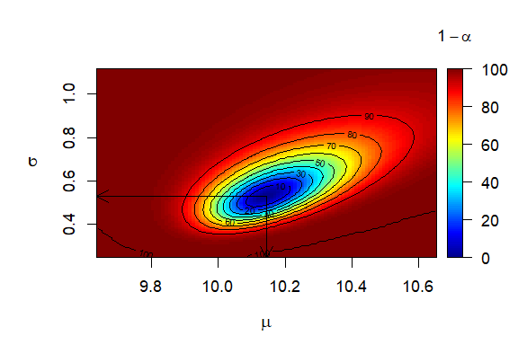

```r
simple.contour(ShockAbsorber.ld,
               distribution = "lognormal",
               show.confidence = T)
```

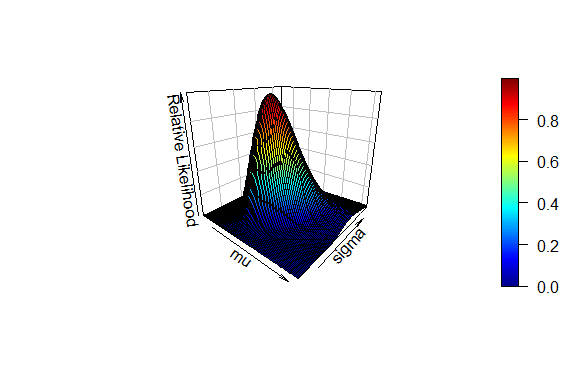

```r
simple.contour(ShockAbsorber.ld,
               distribution = "lognormal",
               show.confidence = T,
               threeD = T)
```

simple.contour(ShockAbsorber.ld,“lognormal”,show.confidence = F) simple.contour(ShockAbsorber.ld,“lognormal”,threeD = T) simple.contour(ShockAbsorber.ld,“lognormal”,quantile=.1) simple.contour(ShockAbsorber.ld,“lognormal”,quantile=.3) simple.contour(ShockAbsorber.ld,“lognormal”,quantile=.3,log.quantile=T) simple.contour(ShockAbsorber.ld,“lognormal”,quantile=.3,rel.or.conf=“”) simple.contour(ShockAbsorber.ld,“lognormal”,quantile = .3,threeD = T)

failure.probabilities(ShockAbsorber.mlest,time.vec=seq(5000, 50000, by=2500), digits=13)

# compare lognormal and Weibull

compare.mleprobplot(ShockAbsorber.ld, main.distribution= “Lognormal”, compare.distribution=“Weibull”)

# plot of hazard function

mlehazplot(ShockAbsorber.ld, distribution=“Weibull”, param.loc = “topleft”)

mlehazplot(ShockAbsorber.ld, distribution=“Frechet”)

mlehazplot(ShockAbsorber.ld, distribution=“Lognormal”)

mlehazplot(ShockAbsorber.ld, distribution=“Lognormal”, xlim=c(5000,500000), y.axis=“log”)

mlehazplot(ShockAbsorber.ld, distribution = “Weibull”, time.vec = c(10000,20000,30000))

mlehazplot(ShockAbsorber.ld, distribution = “Weibull”, time.vec = c(10000,20000,30000), parameter.fixed = c(F,T), theta.start = c(9.,2))

# Bearing Cage Data Set

BearingCage.ld <- frame.to.ld(bearingcage, response.column = 1, censor.column = 2, case.weight.column = 3, time.units = “Hours”)

summary(BearingCage.ld)

mleprobplot(BearingCage.ld, distribution = “Weibull”)

mleprobplot(BearingCage.ld, distribution=“Weibull”, parameter.fixed=c(F,T), theta.start=c(2,.6667), sub.title=“sigma = .667 (or beta = 1.5)”)

mleprobplot(BearingCage.ld, distribution=“Weibull”, parameter.fixed=c(F,T), theta.start=c(9.,.5), sub.title=“sigma = .5 (or beta = 2)”)

mleprobplot(BearingCage.ld, distribution=“Weibull”, parameter.fixed=c(F,T), theta.start=c(9.,.3333), sub.title=“sigma = .333 (or beta = 3)”)

tmpgmle.out <- ls2.mle(BearingCage.ld, distribution =“Weibull”, theta.start=c(9,.4))

simple.contour(BearingCage.ld, distribution = “Weibull”, zoom.level = 4, quantile = .1, threeD = TRUE)

simple.contour(BearingCage.ld, distribution = “Weibull”, zoom.level = 4, profile = “x”)

simple.contour(BearingCage.ld, distribution = “Weibull”, zoom.level = 4, profile = “y”)

simple.contour(BearingCage.ld, distribution = “Weibull”, threeD = T, zoom.level = 3, size = 75)

simple.contour(ShockAbsorber.ld,“Weibull”, zoom.level = 3) simple.contour(ShockAbsorber.ld,“Weibull”, threeD=T) tmp <- simple.contour(ShockAbsorber.ld,“Weibull”, zoom.level = 3, size = 50)

# the following requires interaction

# examples of use of compare.mleprobplot

compare.mleprobplot(ShockAbsorber.ld, main.distribution= “Lognormal”,compare.distribution=“Weibull”)

compare.mleprobplot(BearingCage.ld,main.distribution= “Lognormal”,compare.distribution=“Weibull”,xlim=c(201,9900),ylim=c(.0001,.5),time.range = c(201,9900))

compare.mleprobplot(ShockAbsorber.ld, main.distribution= “Lognormal”,compare.distribution=c(“Weibull”,“Loglogistic”))

compare.mleprobplot(ShockAbsorber.ld, main.distribution= “Lognormal”,xlim=c(100,100000),ylim=c(.005,.9),compare.distribution=c(“Weibull”,“Loglogistic”))

compare.mleprobplot(ShockAbsorber.ld, main.distribution= “Lognormal”,xlim=c(100,50001),ylim=c(.005,.9),compare.distribution=c(“Weibull”,“Loglogistic”,“Exponential”),band.type=“chull”)

compare.mleprobplot(ShockAbsorber.ld, main.distribution= “Lognormal”,xlim=c(100,100000),ylim=c(.005,.9),compare.distribution=c(“Weibull”,“Exponential”),band.type=“chull”)

bulb.ld <- frame.to.ld(bulb, response.column = 1, data.title = “Bulb Data”, time.units = “Hours”)

mlest(bulb.ld,“lognormal”)

simple.contour(bulb.ld,“lognormal”, quantile = .5)

# Here are some examples of the “simple” contours and profiles using lower-level functions

# Here we have the eta parameter on the x axis

ShockAbsorber.likelihood.grid.out <- simple.grid(data.ld=ShockAbsorber.ld,distribution=“Weibull”) plot.simple.contour(contour.indicators=c(.001,.01,.1,.5,.9),do.persp=F,rel.or.conf=“Relative Likelihood”,likelihood.grid.out=ShockAbsorber.likelihood.grid.out) profile.plot(profile.grid(ShockAbsorber.likelihood.grid.out, which = “x”)) profile.plot(profile.grid(ShockAbsorber.likelihood.grid.out, which = “y”)) profile.plot(profile.grid(ShockAbsorber.likelihood.grid.out, which = “y”),log.axis=TRUE)

# Here we have the 0.1 quantile on the x axis

ShockAbsorber.likelihood.grid.out <- simple.grid(data.ld=ShockAbsorber.ld,distribution=“Weibull”,the.quantile=0.1) plot.simple.contour(contour.indicators=c(50., 95.),do.persp=T,rel.or.conf=“Joint confidence region”,the.quantile=0.1,likelihood.grid.out=ShockAbsorber.likelihood.grid.out) plot.simple.contour(contour.indicators=c(50., 95.),do.persp=F,rel.or.conf=“Joint confidence region”,the.quantile=0.1,likelihood.grid.out=ShockAbsorber.likelihood.grid.out) plot.simple.contour(contour.indicators=c(.001,.01,.1,.5,.9),do.persp=F,rel.or.conf=“Relative Likelihood”,the.quantile=0.1,likelihood.grid.out=ShockAbsorber.likelihood.grid.out) profile.plot(profile.grid(ShockAbsorber.likelihood.grid.out, which = “x”)) profile.plot(profile.grid(ShockAbsorber.likelihood.grid.out, which = “y”))

plot.simple.contour(contour.indicators=c(50., 95.),do.persp=TRUE,rel.or.conf=“Joint confidence region”,the.quantile=0.1,likelihood.grid.out=ShockAbsorber.likelihood.grid.out)

# The “brute-force” profileing code below needs a little more work to get it working 100% again.

# The profiling is done on the “stable parameters” used in estimation

# These codes are rather general, but were designed to do the figures in the book.

# They were never optimized for user-friendlyness

# two.dim.profile and one.dim.profile compute (possibly using a lot of computer time)

# and the profiles and automatically creates an object

# Then there the folowing commands are used to make the plot(s).

ShockAbsorber.weibull.gmle.out <- ls.mle(ShockAbsorber.ld, distribution = “Weibull”)

# short test

two.dim.profile(ShockAbsorber.weibull.gmle.out, profile.on.list = NULL,which=c(1,2), size = c(2,2), range.list = list(c(9.0,10.4),c(-1.8,-.1)),monitor=1)

two.dim.profile(ShockAbsorber.weibull.gmle.out, profile.on.list = NULL,which=c(1,2),size = c(25,25), range.list = list(c(9.0,10.4),c(-1.8,-.1)))

profile.contour(ShockAbsorber.weibull.gmle.outstruct1x2,variable.namey=“log(sigma)”)

conf.contour(ShockAbsorber.weibull.gmle.outstruct1x2,transformationy=“log”,variable.namey=“log(sigma)” )

# short test

one.dim.profile(ShockAbsorber.weibull.gmle.out,size = 2, range.list = list(c(9.0,10.2),c(-1.8,-.4)))

one.dim.profile(ShockAbsorber.weibull.gmle.out,size = 200, range.list = list(c(9.8,10.8),c(-1.8,-.4)))

profile.plot(ShockAbsorber.weibull.gmle.outstruct1)

profile.plot(transtruct(ShockAbsorber.weibull.gmle.outstruct1,exp),variable.name=“eta”)

profile.plot(ShockAbsorber.weibull.gmle.outstruct2)

profile.plot(transtruct(ShockAbsorber.weibull.gmle.outstruct2,exp),variable.name=“sigma”)

# define the transformation on the fly to get beta=exp(-log(sigma))

profile.plot(transtruct(ShockAbsorber.weibull.gmle.outstruct2,function(x){exp(-x)}),variable.name=“beta”)

# short test

two.dim.profile(ShockAbsorber.weibull.gmle.out, profile.on.list = NULL,which=c(5,3), special.stuff.profile=list(spec.quantile=.1),profile.setup=quantile.profile.setup, profile.stable.parameters = quantile.profile.stable.parameters,size = c(4,4), range.list =list(c(9.8,10.8),c(-1.8,-.4),c(.165,.670),NULL,c(5000,20000)))

two.dim.profile(ShockAbsorber.weibull.gmle.out, profile.on.list = NULL,which=c(5,3), special.stuff.profile=list(spec.quantile=.1),profile.setup=quantile.profile.setup, profile.stable.parameters = quantile.profile.stable.parameters,size = c(20,20), range.list =list(c(9.8,10.8),c(-1.8,-.4),c(.165,.670),NULL,c(5000,20000)))

profile.contour(ShockAbsorber.weibull.gmle.outstruct5x3,variable.namex=“t_.01”,variable.namey=“sigma”,levels = c(0.01, .1,0.2, 0.4, 0.7, 0.9) )

conf.contour(ShockAbsorber.weibull.gmle.outstruct5x3,levels = c(50,90,99))

one.dim.profile(ShockAbsorber.weibull.gmle.out, profile.on.list = 5,special.stuff.profile = list(spec.quantile = .1), size = 200, profile.setup = quantile.profile.setup,profile.stable.parameters = quantile.profile.stable.parameters, range.list = list(c(5000,20000)),addname=“t.1”)

one.dim.profile(ShockAbsorber.weibull.gmle.out, profile.on.list = 5,special.stuff.profile = list(spec.quantile = .632), size = 200, profile.setup = quantile.profile.setup,profile.stable.parameters = quantile.profile.stable.parameters, range.list = list(c(5000,20000)),addname=“eta”)

profile.plot(ShockAbsorber.weibull.gmle.outstruct5t.1)

one.dim.profile(ShockAbsorber.weibull.gmle.out, profile.on.list = 6,special.stuff.profile = list(spec.time=10000), size = 200, profile.setup = quantile.profile.setup, profile.stable.parameters = quantile.profile.stable.parameters,range.list = list(c(.001,.2)),addname=“F10k”)

profile.plot(ShockAbsorber.weibull.gmle.outstruct6F10k)

one.dim.profile(ShockAbsorber.weibull.gmle.out, profile.on.list = 6, special.stuff.profile = list(spec.time=20000), size = 200, profile.setup = quantile.profile.setup, profile.stable.parameters = quantile.profile.stable.parameters, range.list = list(c(.12,.5)),addname=“F20k”)

profile.plot(ShockAbsorber.weibull.gmle.outstruct6F20k)